# Reproducibility and Good Practices in Science

Pietro Franceschi | pietro.franceschi@fmach.it

## Why does this matter?

Science is the best tool we have to understand the natural world.

But science is done by **humans**, and humans make mistakes — or worse.

The question is not *whether* errors happen, but **whether we can detect and correct them**.

## The Scientific Method

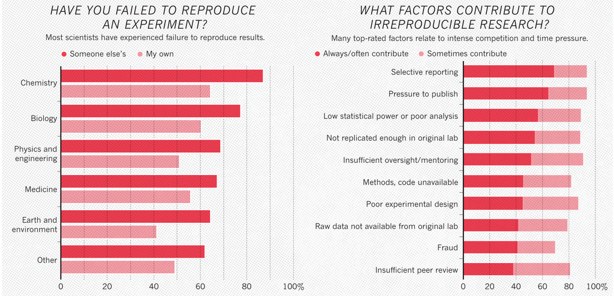

Baker, M. (2016). 1,500 scientists lift the lid on reproducibility. *Nature*, 533, 452–454. Survey of **1,576 researchers**.

The cornerstone of science is **reproducibility**: an independent group must be able to repeat your experiment and obtain the same result.

## What can go wrong?

- **Poor experimental design** → systematic bias
- **Inadequate statistical analysis** → spurious findings
- **Data analysis errors** → wrong conclusions from correct data
- **Confirmation bias** → seeing what we want to see
- **Fraud and misconduct** → active manipulation

## A spectrum of failure

⚠️ **The “reproducibility crisis”**  
A large fraction of published scientific results cannot be reproduced by independent groups. Estimates range from **50% to 70%** of findings in some fields.

We will look at **three real cases** spanning different failure modes:

1. Honest delusion — Benveniste & homeopathy (Nature, 1988)
2. Fatal errors — The Potti scandal at Duke University
3. Correlation is not causation — Chocolate and Nobel Prizes (NEJM, 2012)

# Case 1: The Benveniste Affair

## The original claim

In **June 1988**, *Nature* published a paper by Dayenas, Beauvais, and **J. Benveniste** from INSERM 200, Paris.

The claim: human basophils degranulate in response to anti-IgE antibodies diluted to **10⁻¹²⁰** — far beyond Avogadro’s limit.

Not a single antibody molecule could be present in the solution.

[figure not shown]

## What does it mean?

If anti-IgE retains its biological effectiveness at $10^{-120}$ dilution…

…then **water has memory** of the molecules once dissolved in it.

This would be the **scientific basis for homeopathy**.

**Nature published it anyway** — with an unprecedented *editorial reservation*, and on the condition that an independent team could investigate the laboratory.

## Nature sends an investigation team

The team that visited INSERM 200 in July 1988:

- **John Maddox** — Editor of *Nature*
- **James Randi** — Professional magician and skeptic (MacArthur Fellow)
- **Walter W. Stewart** — Expert in scientific fraud and misconduct (NIH)

One week on-site. Access to **laboratory notebooks**. They imposed **strictly blinded** protocols.

## The result: a delusion

[figure not shown]

*Nature* Vol. 334, **28 July 1988**

The investigators concluded:

> *“We conclude that there is no substantial basis for the claim that anti-IgE at high dilution retains its biological effectiveness.”*

## What went wrong?

- **No serious blinding** — the person counting cells knew which tubes were “active”
- **Observer bias** — samples that did not “work” were excluded or re-run
- **Data errors of the magnitude that would be expected** from sampling noise
- **Confirmation bias** — the word “working” was used only for positive results
- **Financial conflict of interest** — two co-authors were paid by a homeopathic company

## The lesson from Benveniste

⚠️ **Extraordinary claims require extraordinary evidence**  
Blinding, independent replication, and rigorous documentation are not bureaucratic obstacles — they are the defences against our own wishful thinking.

Benveniste was probably not lying — he genuinely believed his results.

That is precisely what makes this case so instructive.

# Case 2: The Potti Scandal

## The promise: personalised cancer therapy

Starting in **2006**, Anil Potti and colleagues at **Duke University** published a series of high-profile papers.

The claim: microarray **gene expression signatures** from cancer cell lines can predict which drug a patient will respond to.

Patients were being **enrolled in clinical trials** and allocated to treatment arms on this basis.

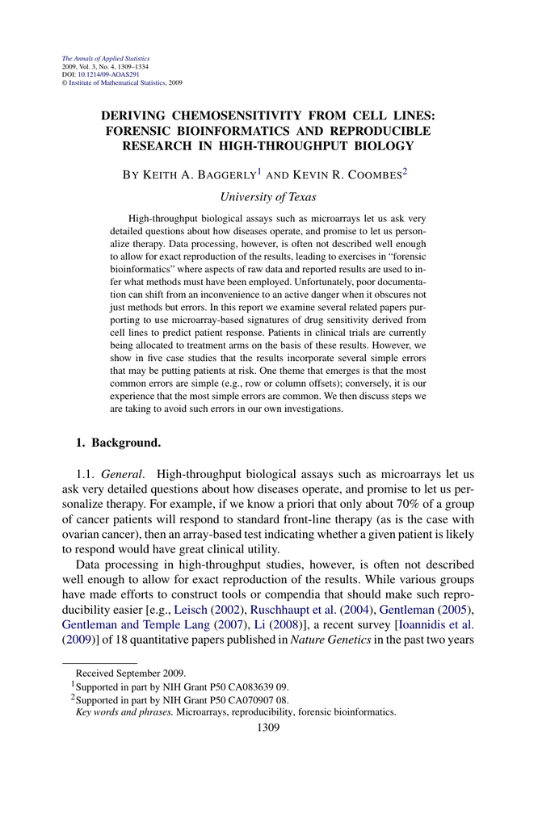

## The forensic bioinformatics

Keith Baggerly and Kevin Coombes at **MD Anderson** tried to reproduce the results as collaborators.

They could not. So they did something remarkable: they reverse-engineered the analyses from the published figures.

*“Data processing is often not described well enough to allow for exact reproduction of the results, leading to exercises in **forensic bioinformatics**.”*  
— Baggerly & Coombes, *Ann. Appl. Stat.* 2009

## What they found

The errors were **remarkably simple**:

- **Off-by-one row/column shifts** when merging data tables
- **Swapped sensitive/resistant labels** — the signature would treat patients with the *opposite* drug
- **Wrong dataset** used for validation — an acute leukemia dataset used to validate a solid tumor predictor
- **Reuse of training data** as “independent” test sets

The most common errors are simple errors.

## The consequences

- Three **clinical trials** were placed on hold (2010)
- Multiple papers **retracted** from high-profile journals
- Potti **resigned** from Duke
- Duke University paid **$10 million** to settle lawsuits from patients
- A **US Senate investigation** was launched into clinical trial oversight

⚠️ **This was not fraud in the traditional sense**  
The errors were “simple” — but they were never caught because the raw data and analysis code were never shared.

## The lesson from Potti

**Reproducible research is a patient safety issue.**

- Share raw data — not just summary tables
- Share analysis code — not just methods paragraphs
- **Independent reanalysis** should be possible and routine
- High-throughput data creates a gap between complexity and intuition that makes errors nearly invisible

> *“Poor documentation can shift from an inconvenience to an active danger when it obscures not just methods but errors.”* — Baggerly & Coombes

# Case 3: Chocolate and Nobel Prizes

## Published in the New England Journal of Medicine

In **October 2012**, Franz Messerli published in *NEJM* (one of the most prestigious medical journals):

**“Chocolate Consumption, Cognitive Function, and Nobel Laureates”**

The logic: flavonoids in chocolate improve cognitive function → countries that eat more chocolate should have more Nobel laureates.

[figure not shown]

## The statistics

The correlation between per-capita chocolate consumption and Nobel laureates per 10 million population across 23 countries:

$$r = 0.791, \quad P <
0.0001$$

Highly statistically significant.

To increase a country’s Nobel laureate count by **1**, it would need to increase chocolate consumption by **0.4 kg per capita per year**.

The paper **concludes**: *“Chocolate consumption enhances cognitive function, which is a sine qua non for winning the Nobel Prize.”*

## What is wrong here?

- **Correlation ≠ causation** — a fundamental principle
- **Ecological fallacy** — country-level averages say nothing about individuals
- **Reverse causation** — wealthy, highly-educated countries both consume more chocolate *and* produce more Nobel laureates
- **Confounding** — GDP, research funding, education, climate… all correlated with both variables
- **No mechanism established** — the flavonoid hypothesis is extrapolated far beyond the evidence

## Why did it get published?

The paper was submitted as **“Occasional Notes”** — a lighter format in NEJM.

The author later acknowledged it was partly tongue-in-cheek.

But the paper has been cited **hundreds of times**, often uncritically, as evidence for dietary effects on brain function.

**The lesson:** the prestige of a journal does not guarantee the validity of a finding. **Critical reading is always required.**

## The lesson from chocolate & Nobel prizes

**Statistically significant ≠ scientifically meaningful.**

- Observational studies cannot establish causation
- A p-value tells you the probability of the data given no effect — it does not tell you **why** the effect exists
- With enough variables, spurious correlations are inevitable
- Always ask: *What is the plausible mechanism? What are the confounders?*

# Three Cases, Common Threads

## What connects them?

| Case | Main failure |
| --- | --- |
| Benveniste | Confirmation bias, lack of blinding |
| Potti | Undocumented analysis, no data sharing |
| Chocolate/Nobel | Confounding, correlation ≠ causation |

All three were published in top journals.

All three were eventually corrected — but only after **harm was done**.

## The path forward

- **Pre-register** your hypotheses before collecting data
- **Share** raw data and analysis code (open science)
- **Blind** your analyses where possible
- **Report effect sizes**, not just p-values
- Embrace **reproducible workflows** (R Markdown, Jupyter, …)
- **Replicate** before acting on findings, especially high-stakes ones

## Take-home message

Reproducibility is not a bureaucratic burden.

It is the mechanism by which science corrects itself — and the guarantee that our findings are worth building on.

**In metabolomics**, where data matrices are large, analysis pipelines are complex, and the pressure to find biomarkers is high, these principles are not optional.